# Seed Rain Analysis

## Setup and Overview

### **Quantifying seed rain patterns in a remnant and a chronosequence of restored tallgrass prairies in north central Missouri**

**Files:**

1. *Seed_Data_2019.xlsx* - contains seed rain data
2. *Seed_Rain_Date.xlsx* - contains lumped seed data per week for each site
3. *Seed_Rain_Traits_Data.xlsx* - species list and trait data

**R Version:** R 4.2.2

**RStudio Version:** 2023.03.0+386

**Package Version:** Found in the .readme document in GitHub Repository

**Last updated: 24 October 2023**

### Libraries and Files

```r
## Clear environment
rm(list=ls())

## Libraries
# Import excel files

library(readxl)

# Data cleaning and visualization
library(tidyverse)

# Community ecology functions (NMDS, diversity indices, etc.)
library(vegan)

# Package needed to do contrasts
library(emmeans)

# Export dataframes to excel files
library(writexl)

# Dimensions check for NMDS stress
library(goeveg)

# Needed in order to install and load the pairwiseAdonis package
## install.packages("devtools")
## library(devtools)
## install_github("pmartinezarbizu/pairwiseAdonis/pairwiseAdonis")

# Function for pairwise PERMANOVA tests
library(pairwiseAdonis)

# Function that allows us to fit a GLM with the negative binomial distribution
library(MASS)

# Makes grided figures
library(cowplot)

# Functions that let you plot ordiellipse in ggplot
library(tcltk)
library(BiodiversityR)


# Function that repels geom_text so that text labels don't overlap
library(ggrepel)

# Function that helps me create tables
library(flextable)

# Function that allows me to export tables to word
library(officer)

# Function that gets means, sds, etc. easily
library(mosaic)
```

```r
#write_xlsx(Seed_Data_Lumped, "Seed_Data_Lumped.xlsx")
```

## Analysis 1: Are there differences in the quantity of seed rain between sites?

### **Are there differences in the quantity of seed rain between sites?**

### Analysis 1: Fitting the Model

```
## # A tibble: 4 × 3
##   Plot    Mean      Var
##   <fct>  <dbl>    <dbl>
## 1 TP     2081. 2357768.
## 2 PFCA 1 6240. 7781808.
## 3 PFCA 2 2408. 1278630.
## 4 PFCA 3 1388.  871377.
```

```
##
## Call:
## stats::glm(formula = totseeds ~ Plot, data = Uni_Seed, family = negative.binomial(theta = 3.30979596926592,
##     link = log))
##
## Deviance Residuals:
##      Min        1Q    Median        3Q       Max
## -1.98297  -0.85535  -0.05762   0.52691   2.36242
##
## Coefficients:
##             Estimate Std. Error z value Pr(>|z|)
## (Intercept)   7.6405     0.1740  43.921  < 2e-16 ***
## PlotPFCA 1    1.0983     0.2459   4.466 7.98e-06 ***
## PlotPFCA 2    0.1460     0.2460   0.593   0.5529
## PlotPFCA 3   -0.4051     0.2461  -1.646   0.0997 .
## ---
## Signif. codes:  0 '***' 0.001 '**' 0.01 '*' 0.05 '.' 0.1 ' ' 1
##
## (Dispersion parameter for Negative Binomial(3.3098) family taken to be 1)
##
##     Null deviance: 85.836  on 39  degrees of freedom
## Residual deviance: 41.995  on 36  degrees of freedom
## AIC: 695.03
##
## Number of Fisher Scoring iterations: 1
```

```
##  contrast    estimate    SE  df z.ratio p.value
##  PFCA 1 - TP    1.098 0.266 Inf   4.127  0.0001
##  PFCA 2 - TP    0.146 0.266 Inf   0.548  0.8741
##  PFCA 3 - TP   -0.405 0.266 Inf  -1.521  0.2996
##
## Results are given on the log (not the response) scale.
## P value adjustment: dunnettx method for 3 tests
```

```
##  Plot   response   SE  df asymp.LCL asymp.UCL
##  TP         2081  392 Inf      1439      3009
##  PFCA 1     6240 1174 Inf      4316      9023
##  PFCA 2     2408  453 Inf      1665      3482
##  PFCA 3     1388  261 Inf       959      2007
##
## Confidence level used: 0.95
## Intervals are back-transformed from the log scale
```

### Analysis 1: Visualizing Differences

Code below creates Figure 1A.

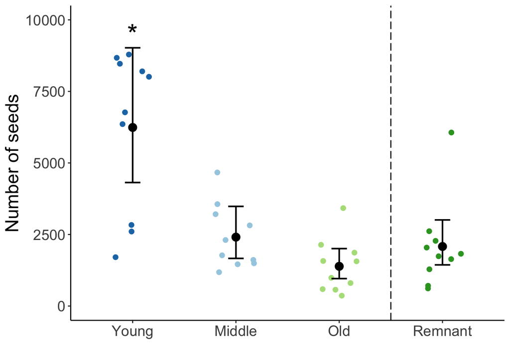

## Analysis 2: Are there differences in the timing of seed rain between sites?

### **Are there differences in the timing of seed rain between sites?**

Code below creates Figure 2.

### Analysis 2: Visualizing differences

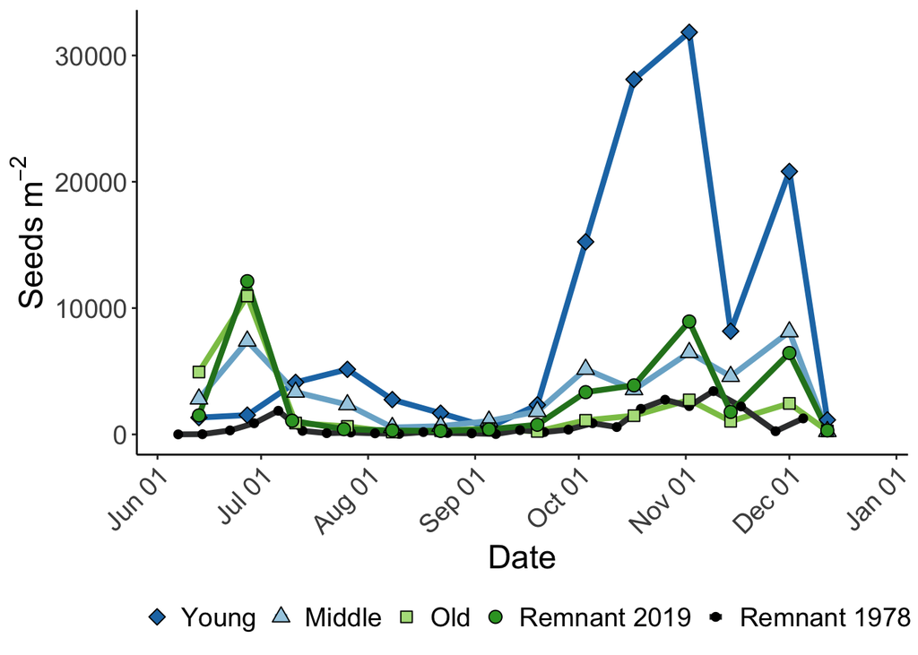

## Analysis 3: Are there differences in the composition of seed rain between sites?

### **Are there differences in the composition of seed rain between sites?**

*Note that using Jaccard dissimilarity and presence/absence produced similar results to Bray-Curtis (Not shown).*

### Analysis 3: NMDS

Code below creates Figure 4.

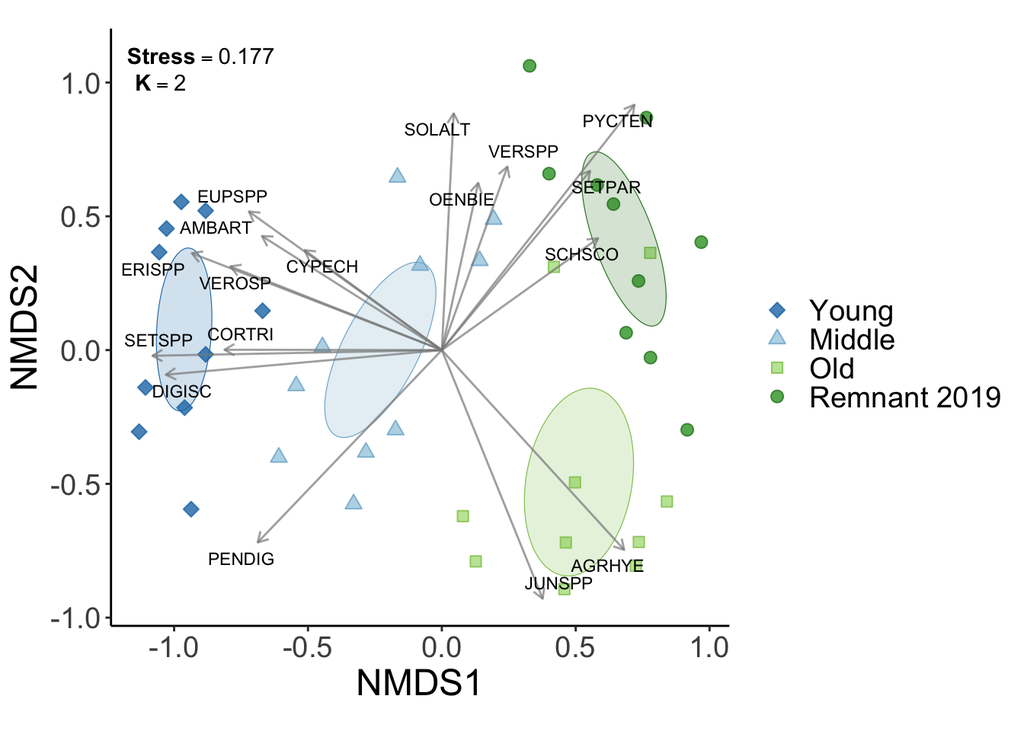

### Analysis 3: PERMANOVA

```
## Permutation test for adonis under reduced model
## Terms added sequentially (first to last)
## Permutation: free
## Number of permutations: 999
##
## adonis2(formula = data.dist.tot ~ as.factor(site), data = seed_com)
##                 Df SumOfSqs      R2      F Pr(>F)
## as.factor(site)  3   5.1625 0.40656 8.2212  0.001 ***
## Residual        36   7.5355 0.59344
## Total           39  12.6980 1.00000
## ---
## Signif. codes:  0 '***' 0.001 '**' 0.01 '*' 0.05 '.' 0.1 ' ' 1
```

```
## $parent_call
## [1] "data.dist.tot ~ as.factor(site) , strata = Null , permutations 999"
##
## $`PFCA 1_vs_PFCA 2`
##          Df SumOfSqs      R2      F Pr(>F)
## site      1   1.1908 0.25173 6.0556  0.001 ***
## Residual 18   3.5395 0.74827
## Total    19   4.7303 1.00000
## ---
## Signif. codes:  0 '***' 0.001 '**' 0.01 '*' 0.05 '.' 0.1 ' ' 1
##
## $`PFCA 1_vs_PFCA 3`
##          Df SumOfSqs      R2      F Pr(>F)
## site      1   2.4309 0.38642 11.336  0.001 ***
## Residual 18   3.8599 0.61358
## Total    19   6.2908 1.00000
## ---
## Signif. codes:  0 '***' 0.001 '**' 0.01 '*' 0.05 '.' 0.1 ' ' 1
##
## $`PFCA 1_vs_TP`
##          Df SumOfSqs      R2      F Pr(>F)
## site      1   2.6392 0.43376 13.789  0.001 ***
## Residual 18   3.4453 0.56624
## Total    19   6.0845 1.00000
## ---
## Signif. codes:  0 '***' 0.001 '**' 0.01 '*' 0.05 '.' 0.1 ' ' 1
##
## $`PFCA 2_vs_PFCA 3`
##          Df SumOfSqs      R2      F Pr(>F)
## site      1   1.2098 0.22826 5.3239  0.001 ***
## Residual 18   4.0902 0.77174
## Total    19   5.2999 1.00000
## ---
## Signif. codes:  0 '***' 0.001 '**' 0.01 '*' 0.05 '.' 0.1 ' ' 1
##
## $`PFCA 2_vs_TP`
##          Df SumOfSqs      R2      F Pr(>F)
## site      1   1.7123 0.31781 8.3857  0.001 ***
## Residual 18   3.6756 0.68219
## Total    19   5.3879 1.00000
## ---
## Signif. codes:  0 '***' 0.001 '**' 0.01 '*' 0.05 '.' 0.1 ' ' 1
##
## $`PFCA 3_vs_TP`
##          Df SumOfSqs      R2      F Pr(>F)
## site      1   1.1422 0.22229 5.1449  0.001 ***
## Residual 18   3.9959 0.77771
## Total    19   5.1381 1.00000
## ---
## Signif. codes:  0 '***' 0.001 '**' 0.01 '*' 0.05 '.' 0.1 ' ' 1
##
## attr(,"class")
## [1] "pwadstrata" "list"
```

## Analysis 4: Are there differences in the diversity of seed rain between sites?

### **Are there differences in the diversity of seed rain between sites?**

```r
Uni_Seed_Diversity_test <- Seed_Data_Lumped %>%
   summarize(Species_richness = n_distinct(SPP6))
```

### Analysis 4: Fitting the models

#### Total Species Richness

```
##  Factor w/ 4 levels "TP","PFCA 1",..: 2 2 2 2 2 2 2 2 2 2 ...
```

```
##
## Call:
## glm(formula = Species_richness ~ Plot, family = "poisson", data = Uni_Seed_Diversity)
##
## Deviance Residuals:
##     Min       1Q   Median       3Q      Max
## -1.7900  -0.7241   0.1619   0.6178   1.9525
##
## Coefficients:
##             Estimate Std. Error z value Pr(>|z|)
## (Intercept)  3.38777    0.05812  58.285  < 2e-16 ***
## PlotPFCA 1   0.19017    0.07856   2.421   0.0155 *
## PlotPFCA 2   0.32336    0.07631   4.237 2.26e-05 ***
## PlotPFCA 3  -0.08456    0.08399  -1.007   0.3141
## ---
## Signif. codes:  0 '***' 0.001 '**' 0.01 '*' 0.05 '.' 0.1 ' ' 1
##
## (Dispersion parameter for poisson family taken to be 1)
##
##     Null deviance: 68.565  on 39  degrees of freedom
## Residual deviance: 34.382  on 36  degrees of freedom
## AIC: 255.36
##
## Number of Fisher Scoring iterations: 4
```

```
##  contrast    estimate     SE  df z.ratio p.value
##  PFCA 1 - TP   0.1902 0.0786 Inf   2.421  0.0426
##  PFCA 2 - TP   0.3234 0.0763 Inf   4.237  0.0001
##  PFCA 3 - TP  -0.0846 0.0840 Inf  -1.007  0.6075
##
## Results are given on the log (not the response) scale.
## P value adjustment: dunnettx method for 3 tests
```

```
##  Plot   rate   SE  df asymp.LCL asymp.UCL
##  TP     29.6 1.72 Inf      26.4      33.2
##  PFCA 1 35.8 1.89 Inf      32.3      39.7
##  PFCA 2 40.9 2.02 Inf      37.1      45.1
##  PFCA 3 27.2 1.65 Inf      24.2      30.6
##
## Confidence level used: 0.95
## Intervals are back-transformed from the log scale
```

#### Native Species Richness

```
##  Factor w/ 4 levels "TP","PFCA 1",..: 2 2 2 2 2 2 2 2 2 2 ...
```

```
##
## Call:
## glm(formula = n_Species_richness ~ Plot, family = "poisson",
##     data = Native_Uni_Seed_Diversity)
##
## Deviance Residuals:
##      Min        1Q    Median        3Q       Max
## -2.04100  -0.65494  -0.00944   0.57426   1.71567
##
## Coefficients:
##             Estimate Std. Error z value Pr(>|z|)
## (Intercept)  3.31419    0.06030  54.960   <2e-16 ***
## PlotPFCA 1   0.02158    0.08482   0.254   0.7991
## PlotPFCA 2   0.18232    0.08165   2.233   0.0256 *
## PlotPFCA 3  -0.13197    0.08824  -1.496   0.1347
## ---
## Signif. codes:  0 '***' 0.001 '**' 0.01 '*' 0.05 '.' 0.1 ' ' 1
##
## (Dispersion parameter for poisson family taken to be 1)
##
##     Null deviance: 46.335  on 39  degrees of freedom
## Residual deviance: 32.141  on 36  degrees of freedom
## AIC: 246.58
##
## Number of Fisher Scoring iterations: 4
```

```
##  contrast    estimate     SE  df z.ratio p.value
##  PFCA 1 - TP   0.0216 0.0848 Inf   0.254  0.9739
##  PFCA 2 - TP   0.1823 0.0816 Inf   2.233  0.0687
##  PFCA 3 - TP  -0.1320 0.0882 Inf  -1.496  0.3127
##
## Results are given on the log (not the response) scale.
## P value adjustment: dunnettx method for 3 tests
```

```
##  Plot   rate   SE  df asymp.LCL asymp.UCL
##  TP     27.5 1.66 Inf      24.4      31.0
##  PFCA 1 28.1 1.68 Inf      25.0      31.6
##  PFCA 2 33.0 1.82 Inf      29.6      36.8
##  PFCA 3 24.1 1.55 Inf      21.2      27.3
##
## Confidence level used: 0.95
## Intervals are back-transformed from the log scale
```

#### Shannon Diversity

```r
# Make Tucker Prairie the reference level

Shannon$Site <- factor(Shannon$Site, levels=c("TP", "PFCA 1", "PFCA 2", "PFCA 3"))

Shannon_sr <- lm(Shannon ~ Site, data = Shannon)
summary(Shannon_sr)
```

```
##
## Call:
## lm(formula = Shannon ~ Site, data = Shannon)
##
## Residuals:
##     Min      1Q  Median      3Q     Max
## -0.7650 -0.2869  0.0378  0.3431  0.6268
##
## Coefficients:
##             Estimate Std. Error t value Pr(>|t|)
## (Intercept)  1.89004    0.13082  14.448   <2e-16 ***
## SitePFCA 1  -0.07867    0.18500  -0.425   0.6732
## SitePFCA 2   0.38781    0.18500   2.096   0.0432 *
## SitePFCA 3  -0.01619    0.18500  -0.088   0.9308
## ---
## Signif. codes:  0 '***' 0.001 '**' 0.01 '*' 0.05 '.' 0.1 ' ' 1
##
## Residual standard error: 0.4137 on 36 degrees of freedom
## Multiple R-squared:  0.1802, Adjusted R-squared:  0.1119
## F-statistic: 2.637 on 3 and 36 DF,  p-value: 0.06439
```

```r
anova(Shannon_sr)
```

```
## Analysis of Variance Table
##
## Response: Shannon
##           Df Sum Sq Mean Sq F value  Pr(>F)
## Site       3 1.3539 0.45130  2.6372 0.06439 .
## Residuals 36 6.1605 0.17113
## ---
## Signif. codes:  0 '***' 0.001 '**' 0.01 '*' 0.05 '.' 0.1 ' ' 1
```

```r
standardize <- emmeans(Shannon_sr, "Site")
contrast(standardize, "trt.vs.ctrl")
```

```
##  contrast    estimate    SE df t.ratio p.value
##  PFCA 1 - TP  -0.0787 0.185 36  -0.425  0.9253
##  PFCA 2 - TP   0.3878 0.185 36   2.096  0.1112
##  PFCA 3 - TP  -0.0162 0.185 36  -0.088  0.9971
##
## P value adjustment: dunnettx method for 3 tests
```

### Analysis 4: Data visualization

Code below creates Figure 3.

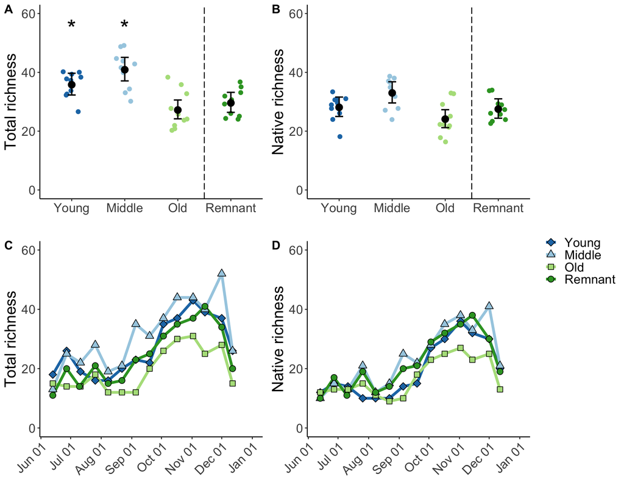

## Analysis 5: Do differences in the quantity of seed rain reflect changes in seed mass traits as community assembly proceeds?

#### Analysis 5: Community Weighted Mean (CWM) seed mass analysis

```
##
## Call:
## glm(formula = weighted_seed_mass ~ Plot, family = gaussian, data = All_CWM)
##
## Deviance Residuals:
##     Min       1Q   Median       3Q      Max
## -0.6801  -0.2440  -0.1410   0.2396   1.1312
##
## Coefficients:
##             Estimate Std. Error t value Pr(>|t|)
## (Intercept)  0.68886    0.13503   5.102  1.1e-05 ***
## PlotPFCA 1   0.24639    0.19096   1.290    0.205
## PlotPFCA 2  -0.04589    0.19096  -0.240    0.811
## PlotPFCA 3   0.23424    0.19096   1.227    0.228
## ---
## Signif. codes:  0 '***' 0.001 '**' 0.01 '*' 0.05 '.' 0.1 ' ' 1
##
## (Dispersion parameter for gaussian family taken to be 0.1823211)
##
##     Null deviance: 7.2679  on 39  degrees of freedom
## Residual deviance: 6.5636  on 36  degrees of freedom
## AIC: 51.221
##
## Number of Fisher Scoring iterations: 2
```

```
## Analysis of Variance Table
##
## Response: weighted_seed_mass
##           Df Sum Sq Mean Sq F value Pr(>F)
## Plot       3 0.7043 0.23477  1.2877 0.2934
## Residuals 36 6.5636 0.18232
```

```
##  Plot   emmean    SE df lower.CL upper.CL
##  TP      0.689 0.135 36    0.415    0.963
##  PFCA 1  0.935 0.135 36    0.661    1.209
##  PFCA 2  0.643 0.135 36    0.369    0.917
##  PFCA 3  0.923 0.135 36    0.649    1.197
##
## Confidence level used: 0.95
```

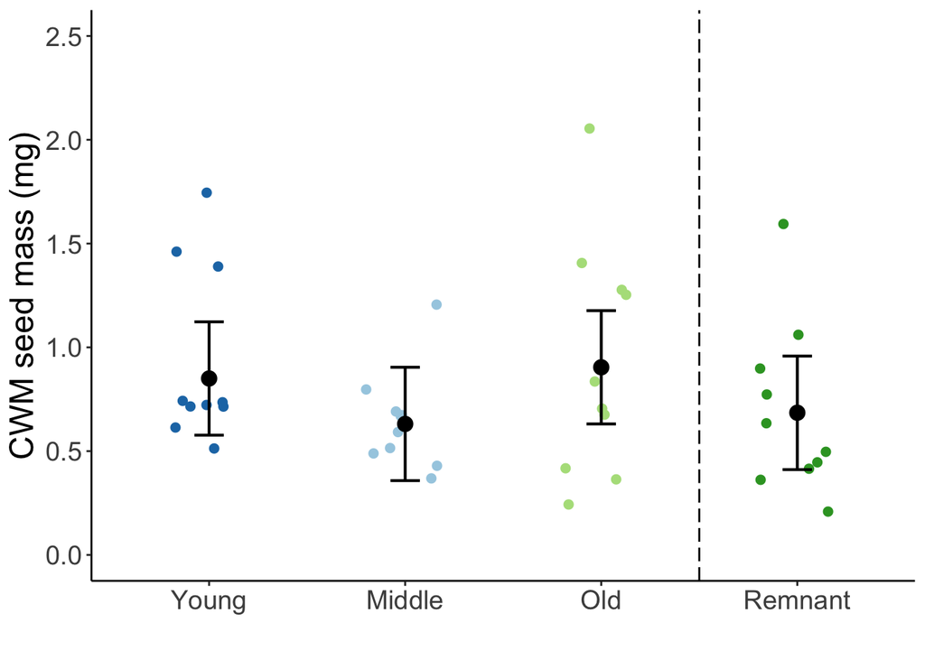

#### Analysis 5: Seed Rain Biomass vs. Site

```
## # A tibble: 4 × 4
##   Plot   Seed_Biomass_mg Seed_Biomass_g Biomass_Density
##   <chr>            <dbl>          <dbl>           <dbl>
## 1 PFCA 1          48618.          48.6             97.2
## 2 PFCA 2          14047.          14.0             28.1
## 3 PFCA 3           9340.           9.34            18.7
## 4 TP              11458.          11.5             22.9
```

```
##  chr [1:1333] "PFCA 1" "PFCA 1" "PFCA 1" "PFCA 1" "PFCA 1" "PFCA 1" ...
```

```
##
## Call:
## glm(formula = Seed_Biomass_mg ~ Plot, family = Gamma(link = "log"),
##     data = All_Captured_Biomass)
##
## Deviance Residuals:
##     Min       1Q   Median       3Q      Max
## -0.6602  -0.3452  -0.0798   0.2279   1.0339
##
## Coefficients:
##             Estimate Std. Error t value Pr(>|t|)
## (Intercept)   7.0438     0.1367  51.546  < 2e-16 ***
## PlotPFCA 1    1.4453     0.1933   7.479 7.81e-09 ***
## PlotPFCA 2    0.2038     0.1933   1.054    0.299
## PlotPFCA 3   -0.2044     0.1933  -1.058    0.297
## ---
## Signif. codes:  0 '***' 0.001 '**' 0.01 '*' 0.05 '.' 0.1 ' ' 1
##
## (Dispersion parameter for Gamma family taken to be 0.1867379)
##
##     Null deviance: 25.0007  on 39  degrees of freedom
## Residual deviance:  5.9399  on 36  degrees of freedom
## AIC: 634.68
##
## Number of Fisher Scoring iterations: 4
```

```
##  contrast    estimate    SE df t.ratio p.value
##  PFCA 1 - TP    1.445 0.193 36   7.479  <.0001
##  PFCA 2 - TP    0.204 0.193 36   1.054  0.5837
##  PFCA 3 - TP   -0.204 0.193 36  -1.058  0.5818
##
## Results are given on the log (not the response) scale.
## P value adjustment: dunnettx method for 3 tests
```

```
##  Plot   response  SE df lower.CL upper.CL
##  TP         1146 157 36      868     1512
##  PFCA 1     4862 664 36     3685     6414
##  PFCA 2     1405 192 36     1065     1853
##  PFCA 3      934 128 36      708     1232
##
## Confidence level used: 0.95
## Intervals are back-transformed from the log scale
```

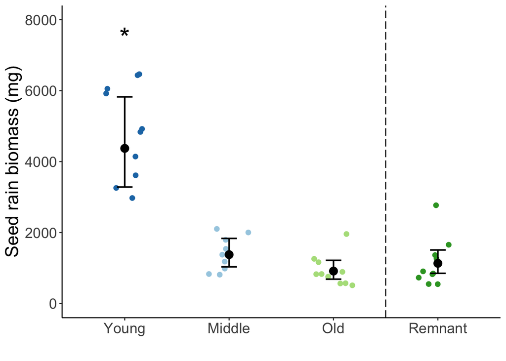

## Supplemental Materials

### Summary tables

Below is the code to make the large summary tables of all seeds and species captured at each time point for each site.

```
## [1] 99.98878 99.95429 99.97116 99.94229
```

**Table SIII.** Total number of seeds captured at all sites. Divide by 200 to get mean number of seeds per turf grass trap. Multiply by 0.5 to convert to seeds per m2 (total trapping area 2 m2).

| Scientific_Name | SPP6 | 2019-06-13 | 2019-06-27 | 2019-07-10 | 2019-07-11 | 2019-07-26 | 2019-08-08 | 2019-08-22 | 2019-09-05 | 2019-09-19 | 2019-10-03 | 2019-10-17 | 2019-11-02 | 2019-11-14 | 2019-12-01 | 2019-12-12 |
| --- | --- | --- | --- | --- | --- | --- | --- | --- | --- | --- | --- | --- | --- | --- | --- | --- |
| Agrostis hyemalis var. hyemalis | AGRHYE | 2010 | 2660 | 73 | 53 | 27 |  | 5 | 5 |  |  | 4 | 2 |  |  |  |
| Sphenopholis obtusata | SPHOBT | 1470 | 1032 | 10 | 73 | 124 | 7 | 2 | 40 | 8 | 1 | 4 | 12 |  | 45 | 1 |
| Juncus sp. | JUNSPP | 933 | 10818 | 340 | 781 | 412 | 109 | 66 | 135 |  |  |  |  |  | 98 |  |
| Cerastium sp. | CERSPP | 158 | 71 |  | 12 | 4 | 6 | 1 | 1 | 10 |  | 1 |  |  |  | 4 |
| Coreopsis lanceolata | CORLAN | 143 | 53 |  | 48 | 42 | 1 | 8 | 28 | 15 | 5 | 7 | 9 |  | 6 |  |
| Veronica sp. | VEROSP | 108 | 77 |  | 16 | 7 | 5 | 6 | 2 | 3 | 3 |  |  |  |  |  |
| Poa pratensis | POAPRA | 105 | 242 | 29 | 302 | 118 | 37 | 26 | 31 | 30 | 2 | 6 | 5 | 2 | 3 | 1 |
| Plantago virginica | PLAVIR | 98 | 99 |  | 46 | 14 | 2 | 4 | 5 |  | 7 | 5 | 9 | 8 | 10 | 2 |
| Myosotis verna | MYOVER | 69 | 58 |  | 11 | 5 | 4 | 1 | 6 | 1 | 1 |  | 3 |  | 1 | 1 |
| Silene antirrhina | SILANT | 65 | 9 |  |  |  |  |  |  |  |  |  |  |  |  |  |
| Triodanis perfoliata | TRIPER | 24 | 22 | 3 | 7 | 13 |  |  |  |  |  |  |  |  |  |  |
| Carex bushii | CARBUS | 17 | 67 | 23 | 28 | 41 | 10 | 13 | 12 | 6 | 1 | 4 | 7 | 3 | 5 | 1 |
| Alopecurus carolinianus | ALOCAR | 17 | 1 |  | 2 |  |  |  |  |  |  |  |  |  |  |  |
| Carex festucacea | CARFES | 14 | 222 | 18 | 85 | 58 | 27 | 19 | 134 | 16 | 14 | 7 | 28 | 4 | 8 | 1 |
| Geranium carolinianum | GERCAR | 13 | 15 |  | 2 |  |  |  |  |  |  |  |  |  |  |  |
| Anagallis minima | ANAMIN | 11 | 15 |  | 67 | 13 | 1 |  | 2 | 9 |  |  |  |  |  |  |
| Capsella bursa-pastoris | CAPBUR | 7 | 12 |  |  | 3 |  |  |  |  |  |  |  |  |  |  |
| Oxalis dillenii | OXADIL | 5 | 4 |  | 1 | 3 | 2 | 3 |  |  | 1 | 3 | 11 | 4 | 1 |  |
| Penstemon digitalis | PENDIG | 4 | 1 |  |  | 35 |  | 6 | 8 | 79 | 1238 | 991 | 4386 | 2426 | 7333 | 128 |
| Tradescantia ohiensis | TRAOHI | 3 | 66 |  | 33 | 12 |  | 7 |  |  | 1 |  | 1 | 1 |  |  |
| Galium aparine | GALAPA | 3 | 9 |  |  | 1 |  |  |  |  |  |  |  |  |  |  |
| Hordeum pusillum | HORPUS | 3 | 7 |  |  |  |  |  |  |  |  |  |  |  |  |  |
| Dichanthelium lanuginosum | DICLAN | 2 | 68 | 25 | 1 | 14 | 14 | 11 | 11 | 19 | 3 | 9 | 9 | 5 | 8 | 3 |
| Lepidium virginicum | LEPVIR | 2 | 11 |  | 3 | 1 |  |  |  |  |  |  |  |  |  |  |
| Unknown spp | UNKSPP | 2 | 4 | 1 |  | 3 |  | 2 | 10 | 3 | 3 | 1 | 3 | 1 |  | 1 |
| Thlaspi arvense | THLARV | 2 | 4 |  |  |  |  | 1 | 4 |  |  |  | 4 | 2 | 2 | 1 |
| Ratibida pinnata | RATPIN | 2 | 1 |  | 1 | 13 |  | 2 | 36 | 38 | 157 | 120 | 167 | 62 | 136 | 5 |
| Eryngium yuccifolium | ERYYUC | 1 | 1 |  | 3 | 1 | 7 | 1 | 9 | 6 | 51 | 109 | 170 | 50 | 82 | 4 |
| Melilotus sp. | MELSPP | 1 |  |  | 22 | 22 | 51 | 162 | 125 | 156 | 62 | 22 | 16 | 10 | 7 |  |
| Hypoxis hirsuta | HYPHIR | 1 |  |  |  |  |  |  |  |  |  |  |  |  |  |  |

[output cut: 100 more lines]

**Table SIV.** Total number of seeds captured at all the remnant prairie (Tucker Prairie). Divide by 50 to get mean number of seeds per turf grass trap. Multiply by 2 to convert to seeds per m2 (total trapping area 0.5 m2).

| Scientific_Name | SPP6 | 2019-06-13 | 2019-06-27 | 2019-07-10 | 2019-07-11 | 2019-07-26 | 2019-08-08 | 2019-08-22 | 2019-09-05 | 2019-09-19 | 2019-10-03 | 2019-10-17 | 2019-11-02 | 2019-11-14 | 2019-12-01 | 2019-12-12 |
| --- | --- | --- | --- | --- | --- | --- | --- | --- | --- | --- | --- | --- | --- | --- | --- | --- |
| Agrostis hyemalis var. hyemalis | AGRHYE | 434 | 1557 | 73 |  | 16 |  | 1 | 3 |  |  |  | 2 |  |  |  |
| Sphenopholis obtusata | SPHOBT | 147 | 93 | 10 |  | 4 |  |  | 1 |  |  |  | 1 |  |  |  |
| Poa pratensis | POAPRA | 89 | 180 | 29 |  | 73 | 15 | 12 | 6 | 2 |  | 2 |  | 2 | 2 |  |
| Silene antirrhina | SILANT | 65 | 9 |  |  |  |  |  |  |  |  |  |  |  |  |  |
| Juncus sp. | JUNSPP | 4 | 3885 | 340 |  | 34 | 31 |  | 32 |  |  |  |  |  |  |  |
| Carex festucacea | CARFES | 4 | 138 | 18 |  | 7 | 16 | 3 | 4 | 4 | 2 | 2 | 3 | 2 | 1 | 1 |
| Plantago virginica | PLAVIR | 4 | 17 |  |  |  |  |  |  |  |  |  |  |  |  |  |
| Oxalis dillenii | OXADIL | 2 |  |  |  |  |  |  |  |  |  |  |  |  |  |  |
| Dichanthelium lanuginosum | DICLAN | 1 | 66 | 25 |  | 14 | 14 | 11 | 10 | 9 | 3 | 9 | 9 | 5 | 8 | 3 |
| Myosotis verna | MYOVER | 1 | 5 |  |  |  |  |  |  |  |  |  |  |  |  |  |
| Hypoxis hirsuta | HYPHIR | 1 |  |  |  |  |  |  |  |  |  |  |  |  |  |  |
| Carex bushii | CARBUS |  | 46 | 23 |  | 22 | 3 | 10 | 7 | 3 | 1 | 1 | 1 | 1 | 1 |  |
| Vulpia octoflora | VULOCT |  | 20 |  |  | 3 | 1 |  |  |  |  |  | 1 |  |  |  |
| Triodanis perfoliata | TRIPER |  | 18 | 3 |  |  |  |  |  |  |  |  |  |  |  |  |
| Lobelia spicata | LOBSPI |  | 16 |  |  | 1 |  |  |  |  |  |  |  |  |  |  |
| Rubus sp. | RUBSPP |  | 4 | 2 |  |  | 34 |  |  |  |  | 1 | 1 |  | 1 |  |
| Carex bicknellii | CARBIC |  | 3 |  |  |  |  |  |  |  |  |  |  |  |  |  |
| Pycnanthemum tenuifolium | PYCTEN |  | 2 | 3 |  | 1 |  | 2 | 35 | 182 | 797 | 717 | 2187 | 400 | 2330 | 63 |
| Vernonia sp. | VERSPP |  | 2 |  |  |  |  |  |  | 1 | 16 | 36 | 26 | 83 | 16 | 15 |
| Unknown spp | UNKSPP |  | 1 | 1 |  | 1 |  |  | 4 | 1 |  | 1 | 1 | 1 |  | 1 |
| Penstemon digitalis | PENDIG |  | 1 |  |  |  |  |  |  |  |  |  |  | 7 | 1 |  |
| Cardamine sp. | CARDSP |  | 1 |  |  |  |  |  |  |  |  |  |  |  |  |  |
| Viola sagittata | VIOSAG |  | 1 |  |  |  |  |  |  |  |  |  |  |  |  |  |
| Erigeron sp. | ERISPP |  |  | 8 |  | 3 |  | 2 | 2 | 12 |  |  |  |  |  |  |
| Polygala sp. | POLSPP |  |  | 3 |  |  | 3 | 2 | 7 | 1 | 1 | 1 |  |  |  |  |
| Barbarea vulgaris | BARVUL |  |  | 2 |  | 11 | 6 | 5 | 8 | 3 | 12 | 9 | 97 | 8 | 38 | 3 |
| Schizachyrium scoparium | SCHSCO |  |  | 2 |  | 1 | 2 |  | 1 | 1 | 89 | 188 | 228 | 35 | 80 | 26 |
| Setaria parviflora | SETPAR |  |  |  |  | 4 | 1 | 8 |  | 4 | 4 | 6 | 6 | 1 | 4 | 2 |
| Linum sulcatum var. sulcatum | LINSUL |  |  |  |  | 3 | 7 | 3 |  |  |  | 4 | 16 | 5 | 15 | 4 |
| Galium obtusum subsp. obtusum | GALOBT |  |  |  |  | 3 | 4 | 6 | 9 | 4 |  | 1 |  | 4 | 6 |  |
| Achillea millefolium | ACHMIL |  |  |  |  | 2 | 19 | 36 | 1 |  | 16 | 3 | 13 | 6 | 8 | 1 |
| Koeleria macrantha | KOEMAC |  |  |  |  | 2 |  |  |  |  |  |  |  |  |  |  |
| Ambrosia artemisiifolia | AMBART |  |  |  |  | 1 |  |  |  | 1 | 1 |  |  | 1 |  |  |
| Lepidium virginicum | LEPVIR |  |  |  |  | 1 |  |  |  |  |  |  |  |  |  |  |
| Scirpus pendulus | SCIPEN |  |  |  |  | 1 |  |  |  |  |  |  |  |  |  |  |
| Crotalaria sagittalis | CROSAG |  |  |  |  |  | 2 | 30 | 28 | 48 | 37 | 24 | 11 | 4 | 1 | 2 |
| Festuca paradoxa | FESPAR |  |  |  |  |  |  | 7 | 3 | 3 | 153 | 5 | 10 | 1 | 2 | 5 |
| Helianthus mollis | HELMOL |  |  |  |  |  |  | 1 | 1 | 4 | 40 | 58 | 54 | 6 | 33 |  |
| Andropogon gerardii | ANDGER |  |  |  |  |  |  |  | 23 |  | 53 | 84 | 223 | 24 | 12 | 2 |
| Desmodium sp. | DESSPP |  |  |  |  |  |  |  | 10 | 20 | 99 | 70 | 29 | 15 | 13 |  |
| Rudbeckia hirta var. pulcherrima | RUDHIR |  |  |  |  |  |  |  | 3 | 8 | 13 | 15 | 30 | 6 | 9 | 2 |
| Acalypha virginica | ACAVIR |  |  |  |  |  |  |  | 2 | 5 | 7 | 3 | 3 |  | 1 |  |
| Euphorbia corollata | EUPCOR |  |  |  |  |  |  |  | 1 | 6 | 1 | 3 | 2 | 1 |  |  |
| Chenopodium album | CHEALB |  |  |  |  |  |  |  | 1 |  |  |  |  |  |  |  |
| Chamaecrista fasciculata | CHAFAS |  |  |  |  |  |  |  |  | 41 | 142 | 49 | 9 | 3 |  |  |
| Cerastium sp. | CERSPP |  |  |  |  |  |  |  |  | 9 |  |  |  |  |  |  |
| Sorghastrum nutans | SORNUT |  |  |  |  |  |  |  |  | 5 | 72 | 149 | 173 | 30 | 29 | 5 |
| Oenothera filiformis | OENFIL |  |  |  |  |  |  |  |  | 5 | 4 | 1 |  | 1 |  |  |
| Digitaria ischaemum | DIGISC |  |  |  |  |  |  |  |  | 2 |  |  |  |  |  |  |
| Lespedeza capitata | LESCAP |  |  |  |  |  |  |  |  |  | 37 | 47 | 17 | 2 | 3 |  |
| Solidago altissima | SOLALT |  |  |  |  |  |  |  |  |  | 36 | 282 | 834 | 58 | 199 | 10 |
| Oenothera biennis | OENBIE |  |  |  |  |  |  |  |  |  | 20 | 124 | 403 | 50 | 301 | 6 |
| Cirsium altissimum | CIRALT |  |  |  |  |  |  |  |  |  | 8 | 3 |  | 2 | 2 |  |
| Conyza canadensis | CONCAN |  |  |  |  |  |  |  |  |  | 5 |  | 3 |  |  | 1 |
| Eryngium yuccifolium | ERYYUC |  |  |  |  |  |  |  |  |  | 1 | 3 | 28 | 5 | 21 |  |
| Sporobolus heterolepis | SPOHET |  |  |  |  |  |  |  |  |  | 1 | 1 |  |  |  |  |
| Melilotus sp. | MELSPP |  |  |  |  |  |  |  |  |  | 1 |  |  | 1 |  |  |
| Amorpha canescens | AMOCAN |  |  |  |  |  |  |  |  |  | 1 |  |  |  |  |  |
| Lycopus americanus | LYCAME |  |  |  |  |  |  |  |  |  |  | 33 |  |  |  |  |
| Agalinis sp. | AGASPP |  |  |  |  |  |  |  |  |  |  | 5 | 27 | 58 | 17 |  |
| Tridens flavus | TRIFLA |  |  |  |  |  |  |  |  |  |  | 1 |  | 1 |  |  |
| Eleocharis sp. | ELESPP |  |  |  |  |  |  |  |  |  |  | 1 |  |  |  |  |
| Euthamia gymnospermoides | EUTGYM |  |  |  |  |  |  |  |  |  |  |  | 10 | 7 | 20 | 1 |
| Symphyotrichum sp. | SYMSPP |  |  |  |  |  |  |  |  |  |  |  | 4 | 8 | 45 | 3 |
| Bidens aristosa | BIDARI |  |  |  |  |  |  |  |  |  |  |  | 3 | 3 |  |  |
| Eupatorium sp. | EUPSPP |  |  |  |  |  |  |  |  |  |  |  | 2 | 28 |  |  |
| Monarda fistulosa subsp. fistulosa | MONFIS |  |  |  |  |  |  |  |  |  |  |  | 2 | 1 |  |  |
| Ratibida pinnata | RATPIN |  |  |  |  |  |  |  |  |  |  |  | 1 | 5 |  |  |
| Hypericum punctatum | HYPPUN |  |  |  |  |  |  |  |  |  |  |  | 1 |  |  |  |
| Rudbeckia subtomentosa | RUDSUB |  |  |  |  |  |  |  |  |  |  |  |  | 4 |  |  |
| Scirpus georgianus | SCIGEO |  |  |  |  |  |  |  |  |  |  |  |  | 4 |  |  |
| Coreopsis tripteris | CORTRI |  |  |  |  |  |  |  |  |  |  |  |  | 2 |  |  |
| Eragrostis spectabilis | ERASPE |  |  |  |  |  |  |  |  |  |  |  |  |  | 1 |  |
| Gentiana sp. | GENSPP |  |  |  |  |  |  |  |  |  |  |  |  |  | 1 |  |
| Lespedeza cuneata | LESCUN |  |  |  |  |  |  |  |  |  |  |  |  |  | 1 |  |
| Verbena hastata | VERHAS |  |  |  |  |  |  |  |  |  |  |  |  |  | 1 |  |
| Lysimachia lanceolata | LYSLAN |  |  |  |  |  |  |  |  |  |  |  |  |  |  | 1 |

**Table SV.** Total number of seeds captured at all the young restored prairie (2-year-old). Divide by 50 to get mean number of seeds per turf grass trap. Multiply by 2 to convert to seeds per m2 (total trapping area 0.5 m2).

| Scientific_Name | SPP6 | 2019-06-13 | 2019-06-27 | 2019-07-10 | 2019-07-11 | 2019-07-26 | 2019-08-08 | 2019-08-22 | 2019-09-05 | 2019-09-19 | 2019-10-03 | 2019-10-17 | 2019-11-02 | 2019-11-14 | 2019-12-01 | 2019-12-12 |
| --- | --- | --- | --- | --- | --- | --- | --- | --- | --- | --- | --- | --- | --- | --- | --- | --- |
| Juncus sp. | JUNSPP | 233 | 318 |  | 52 | 34 |  |  | 2 |  |  |  |  |  |  |  |
| Cerastium sp. | CERSPP | 149 | 61 |  | 11 | 3 | 6 |  |  |  |  |  |  |  |  | 4 |
| Veronica sp. | VEROSP | 102 | 69 |  | 14 | 5 | 3 | 3 |  |  | 2 |  |  |  |  |  |
| Myosotis verna | MYOVER | 64 | 44 |  | 11 | 4 | 4 | 1 | 5 |  | 1 |  | 3 |  | 1 | 1 |
| Plantago virginica | PLAVIR | 50 | 58 |  | 38 | 5 | 1 | 1 |  |  |  |  | 1 | 1 | 1 | 1 |
| Triodanis perfoliata | TRIPER | 24 | 4 |  | 7 | 13 |  |  |  |  |  |  |  |  |  |  |
| Sphenopholis obtusata | SPHOBT | 14 | 6 |  | 1 |  |  |  | 1 |  | 1 | 1 |  |  |  |  |
| Geranium carolinianum | GERCAR | 11 | 15 |  | 2 |  |  |  |  |  |  |  |  |  |  |  |
| Capsella bursa-pastoris | CAPBUR | 5 | 12 |  |  | 1 |  |  |  |  |  |  |  |  |  |  |
| Alopecurus carolinianus | ALOCAR | 3 |  |  |  |  |  |  |  |  |  |  |  |  |  |  |
| Lepidium virginicum | LEPVIR | 2 | 10 |  | 1 |  |  |  |  |  |  |  |  |  |  |  |
| Galium aparine | GALAPA | 2 | 9 |  |  | 1 |  |  |  |  |  |  |  |  |  |  |
| Thlaspi arvense | THLARV | 2 | 4 |  |  |  |  | 1 | 3 |  |  |  | 4 | 1 | 1 |  |
| Oxalis dillenii | OXADIL | 2 | 1 |  | 1 | 3 | 1 | 2 |  |  |  |  | 3 |  | 1 |  |
| Poa pratensis | POAPRA | 1 | 7 |  | 1 | 1 | 10 | 6 |  |  |  |  |  |  |  |  |
| Dichanthelium lanuginosum | DICLAN | 1 | 2 |  | 1 |  |  |  |  | 10 |  |  |  |  |  |  |
| Melilotus sp. | MELSPP | 1 |  |  |  |  |  | 2 | 1 | 9 | 1 |  |  | 1 |  |  |
| Platanus occidentalis | PLAOCC | 1 |  |  |  |  |  |  |  |  |  |  |  |  |  |  |
| Erigeron sp. | ERISPP |  | 78 |  | 1876 | 2483 | 1290 | 625 | 58 | 63 | 40 |  |  |  |  |  |
| Digitaria ischaemum | DIGISC |  | 22 |  | 2 | 1 | 6 | 3 | 1 | 257 | 3637 | 7585 | 3643 | 883 | 556 | 163 |
| Setaria sp. | SETSPP |  | 16 |  |  |  | 1 | 5 | 16 | 208 | 1794 | 1484 | 979 | 107 | 188 | 24 |
| Anagallis minima | ANAMIN |  | 15 |  | 35 | 4 | 1 |  |  |  |  |  |  |  |  |  |
| Barbarea vulgaris | BARVUL |  | 7 |  |  |  |  | 1 |  |  |  |  |  |  |  |  |
| Ambrosia artemisiifolia | AMBART |  | 2 |  |  |  | 1 |  | 4 |  | 15 | 25 | 13 | 3 | 8 | 2 |
| Medicago lupulina | MEDLUP |  | 1 |  |  | 1 |  | 2 | 11 | 2 |  | 1 |  |  |  |  |
| Kummerowia sp. | KUMSPP |  | 1 |  |  |  |  | 1 | 4 | 1 | 20 | 41 | 70 | 56 | 118 | 12 |
| Verbena hastata | VERHAS |  | 1 |  |  |  |  |  |  |  |  |  | 4 |  | 4 | 1 |
| Koeleria macrantha | KOEMAC |  | 1 |  |  |  |  |  |  |  |  |  |  |  |  |  |
| Taraxacum officinale | TAROFF |  | 1 |  |  |  |  |  |  |  |  |  |  |  |  |  |
| Scleria triglomerata | SCLTRI |  |  |  | 4 |  |  |  |  |  |  |  |  |  |  |  |

[output cut: 58 more lines]

**Table SVI.** Total number of seeds captured at all the middle-aged restored prairie (6-7-year-old). Divide by 50 to get mean number of seeds per turf grass trap. Multiply by 2 to convert to seeds per m2 (total trapping area 0.5 m2).

| Scientific_Name | SPP6 | 2019-06-13 | 2019-06-27 | 2019-07-10 | 2019-07-11 | 2019-07-26 | 2019-08-08 | 2019-08-22 | 2019-09-05 | 2019-09-19 | 2019-10-03 | 2019-10-17 | 2019-11-02 | 2019-11-14 | 2019-12-01 | 2019-12-12 |
| --- | --- | --- | --- | --- | --- | --- | --- | --- | --- | --- | --- | --- | --- | --- | --- | --- |
| Sphenopholis obtusata | SPHOBT | 1159 | 863 |  | 72 | 116 | 5 | 2 | 38 | 8 |  | 3 | 11 |  | 45 | 1 |
| Coreopsis lanceolata | CORLAN | 143 | 53 |  | 46 | 39 | 1 | 7 | 28 | 15 | 4 | 7 | 9 |  | 6 |  |
| Plantago virginica | PLAVIR | 42 | 22 |  | 6 | 9 | 1 | 3 | 5 |  | 7 | 5 | 8 | 7 | 9 | 1 |
| Juncus sp. | JUNSPP | 27 | 2511 |  | 512 | 189 | 51 | 10 | 73 |  |  |  |  |  | 98 |  |
| Cerastium sp. | CERSPP | 9 | 10 |  | 1 | 1 |  | 1 | 1 | 1 |  |  |  |  |  |  |
| Poa pratensis | POAPRA | 5 | 51 |  | 298 | 44 | 12 | 8 | 25 | 28 | 2 | 4 | 5 |  | 1 | 1 |
| Veronica sp. | VEROSP | 5 | 8 |  | 2 | 2 | 2 | 3 | 2 | 3 | 1 |  |  |  |  |  |
| Myosotis verna | MYOVER | 4 | 4 |  |  | 1 |  |  | 1 |  |  |  |  |  |  |  |
| Hordeum pusillum | HORPUS | 3 | 7 |  |  |  |  |  |  |  |  |  |  |  |  |  |
| Ratibida pinnata | RATPIN | 2 | 1 |  | 1 | 12 |  | 1 | 21 | 27 | 20 | 41 | 45 | 9 | 47 |  |
| Geranium carolinianum | GERCAR | 2 |  |  |  |  |  |  |  |  |  |  |  |  |  |  |
| Carex bushii | CARBUS | 1 | 12 |  | 7 | 9 | 1 | 1 | 4 | 2 |  | 1 | 2 | 1 | 2 | 1 |
| Unknown spp | UNKSPP | 1 | 2 |  |  | 1 |  | 1 | 4 |  | 2 |  |  |  |  |  |
| Galium aparine | GALAPA | 1 |  |  |  |  |  |  |  |  |  |  |  |  |  |  |
| Erigeron sp. | ERISPP |  | 70 |  | 528 | 432 | 84 | 66 | 3 | 7 |  |  |  |  |  |  |
| Monarda fistulosa subsp. fistulosa | MONFIS |  | 18 |  |  | 4 | 4 | 8 | 35 | 32 | 107 | 24 | 44 | 16 | 64 |  |
| Setaria sp. | SETSPP |  | 14 |  | 11 |  |  |  | 7 | 60 | 275 | 205 | 115 | 70 | 54 |  |
| Coreopsis palmata | CORPAL |  | 13 |  | 17 | 3 | 1 |  |  |  |  |  |  |  |  |  |
| Festuca arundinacea | FESARU |  | 9 |  | 2 |  | 1 |  |  |  |  |  |  |  |  |  |
| Carex cephalophora | CARCEP |  | 8 |  |  |  |  |  |  |  |  |  |  |  |  |  |
| Medicago lupulina | MEDLUP |  | 6 |  | 52 | 95 | 65 | 76 | 50 | 24 | 7 | 7 |  | 1 | 5 |  |
| Bromus japonicus | BROJAP |  | 4 |  | 5 | 2 | 1 |  | 5 |  |  |  |  |  | 4 |  |
| Barbarea vulgaris | BARVUL |  | 4 |  | 2 | 1 |  |  | 3 | 2 |  | 2 |  | 3 | 7 | 1 |
| Oxalis dillenii | OXADIL |  | 2 |  |  |  |  | 1 |  |  |  | 1 | 5 | 3 |  |  |
| Rumex crispus | RUMCRI |  | 2 |  |  |  |  |  |  |  |  |  |  |  |  |  |
| Pycnanthemum tenuifolium | PYCTEN |  | 1 |  |  | 5 | 2 | 2 | 8 | 215 | 230 | 92 | 453 | 306 | 356 | 37 |
| Eryngium yuccifolium | ERYYUC |  | 1 |  |  | 1 |  |  |  |  | 4 | 14 | 32 | 21 | 14 | 3 |
| Persicaria longiseta | PERLON |  | 1 |  |  |  |  |  |  |  |  |  |  |  |  |  |
| Koeleria macrantha | KOEMAC |  |  |  | 65 | 107 | 17 | 10 | 58 | 7 |  |  |  |  | 1 |  |
| Melilotus sp. | MELSPP |  |  |  | 22 | 16 | 22 | 103 | 79 | 119 | 50 | 15 | 14 | 8 | 6 |  |

[output cut: 53 more lines]

**Table SVII.** Total number of seeds captured at all the oldest restored prairie (15-year-old). Divide by 50 to get mean number of seeds per turf grass trap. Multiply by 2 to convert to seeds per m2 (total trapping area 0.5 m2).

| Scientific_Name | SPP6 | 2019-06-13 | 2019-06-27 | 2019-07-10 | 2019-07-11 | 2019-07-26 | 2019-08-08 | 2019-08-22 | 2019-09-05 | 2019-09-19 | 2019-10-03 | 2019-10-17 | 2019-11-02 | 2019-11-14 | 2019-12-01 | 2019-12-12 |
| --- | --- | --- | --- | --- | --- | --- | --- | --- | --- | --- | --- | --- | --- | --- | --- | --- |
| Agrostis hyemalis var. hyemalis | AGRHYE | 1576 | 1103 |  | 53 | 11 |  | 4 | 2 |  |  | 4 |  |  |  |  |
| Juncus sp. | JUNSPP | 669 | 4104 |  | 217 | 155 | 27 | 56 | 28 |  |  |  |  |  |  |  |
| Sphenopholis obtusata | SPHOBT | 150 | 70 |  |  | 4 | 2 |  |  |  |  |  |  |  |  |  |
| Carex bushii | CARBUS | 16 | 9 |  | 20 | 10 | 6 | 2 | 1 | 1 |  | 2 | 4 |  | 2 |  |
| Alopecurus carolinianus | ALOCAR | 14 | 1 |  | 2 |  |  |  |  |  |  |  |  |  |  |  |
| Anagallis minima | ANAMIN | 11 |  |  | 15 |  |  |  |  |  |  |  |  |  |  |  |
| Carex festucacea | CARFES | 10 | 84 |  | 85 | 51 | 11 | 16 | 130 | 12 | 12 | 5 | 17 | 2 | 7 |  |
| Poa pratensis | POAPRA | 10 | 4 |  | 3 |  |  |  |  |  |  |  |  |  |  |  |
| Penstemon digitalis | PENDIG | 4 |  |  |  | 35 |  |  |  | 1 | 22 | 58 | 152 | 106 | 277 | 7 |
| Tradescantia ohiensis | TRAOHI | 3 | 66 |  | 33 | 12 |  | 7 |  |  | 1 |  | 1 | 1 |  |  |
| Plantago virginica | PLAVIR | 2 | 2 |  | 2 |  |  |  |  |  |  |  |  |  |  |  |
| Capsella bursa-pastoris | CAPBUR | 2 |  |  |  | 2 |  |  |  |  |  |  |  |  |  |  |
| Oxalis dillenii | OXADIL | 1 | 1 |  |  |  | 1 |  |  |  | 1 | 2 | 3 | 1 |  |  |
| Unknown spp | UNKSPP | 1 | 1 |  |  |  |  |  | 1 |  | 1 |  |  |  |  |  |
| Eryngium yuccifolium | ERYYUC | 1 |  |  | 3 |  | 7 | 1 | 9 | 6 | 46 | 92 | 110 | 23 | 47 | 1 |
| Veronica sp. | VEROSP | 1 |  |  |  |  |  |  |  |  |  |  |  |  |  |  |
| Vulpia octoflora | VULOCT |  | 14 |  | 7 | 1 | 1 | 2 |  |  |  |  |  |  |  |  |
| Achillea millefolium | ACHMIL |  | 14 |  |  |  |  |  |  |  |  |  | 2 |  |  |  |
| Myosotis verna | MYOVER |  | 5 |  |  |  |  |  |  | 1 |  |  |  |  |  |  |
| Lepidium virginicum | LEPVIR |  | 1 |  | 1 |  |  |  |  |  |  |  |  |  |  |  |
| Erigeron sp. | ERISPP |  |  |  | 10 | 6 | 9 | 1 | 1 | 5 |  |  |  |  |  |  |
| Andropogon gerardii | ANDGER |  |  |  | 1 |  |  |  |  | 1 | 10 | 9 | 11 | 1 | 9 |  |
| Carex annectens | CARANN |  |  |  |  | 15 |  |  |  |  |  |  |  |  |  |  |
| Melilotus sp. | MELSPP |  |  |  |  | 6 | 29 | 57 | 45 | 28 | 10 | 7 | 2 |  | 1 |  |
| Amorpha canescens | AMOCAN |  |  |  |  | 4 | 1 | 1 |  | 1 |  |  | 1 | 2 | 13 |  |
| Cyperus acuminatus | CYPACU |  |  |  |  | 2 |  |  | 5 | 4 | 12 | 5 | 6 | 4 | 7 |  |
| Pycnanthemum tenuifolium | PYCTEN |  |  |  |  | 1 | 1 |  | 7 | 10 | 60 | 51 | 85 | 54 | 112 |  |
| Medicago lupulina | MEDLUP |  |  |  |  | 1 |  |  |  | 9 | 3 |  |  |  |  |  |
| Ratibida pinnata | RATPIN |  |  |  |  | 1 |  |  |  |  |  | 1 | 4 |  |  |  |
| Festuca paradoxa | FESPAR |  |  |  |  | 1 |  |  |  |  |  |  |  |  |  |  |
| Acalypha virginica | ACAVIR |  |  |  |  |  | 1 |  | 1 | 1 |  | 1 |  |  |  |  |
| Mollugo verticillata | MOLVER |  |  |  |  |  |  | 2 | 1 |  |  |  | 1 |  | 7 |  |
| Kummerowia sp. | KUMSPP |  |  |  |  |  |  | 1 |  |  |  | 9 | 7 | 3 |  |  |
| Sorghastrum nutans | SORNUT |  |  |  |  |  |  |  | 1 | 12 | 140 | 242 | 237 | 107 | 108 | 4 |
| Chamaecrista fasciculata | CHAFAS |  |  |  |  |  |  |  |  | 13 | 31 | 5 | 3 |  |  |  |
| Oenothera filiformis | OENFIL |  |  |  |  |  |  |  |  | 6 | 24 | 3 | 3 |  |  |  |
| Desmodium sp. | DESSPP |  |  |  |  |  |  |  |  | 5 | 6 | 6 |  |  | 1 | 1 |
| Rudbeckia hirta var. pulcherrima | RUDHIR |  |  |  |  |  |  |  |  | 2 | 61 | 4 | 88 | 7 | 32 |  |
| Strophostyles leiosperma | STRLEI |  |  |  |  |  |  |  |  | 2 | 3 |  |  |  |  |  |
| Schizachyrium scoparium | SCHSCO |  |  |  |  |  |  |  |  | 1 | 69 | 61 | 108 | 49 | 31 | 1 |
| Lespedeza capitata | LESCAP |  |  |  |  |  |  |  |  |  | 21 | 37 | 76 | 5 | 33 | 3 |
| Rudbeckia subtomentosa | RUDSUB |  |  |  |  |  |  |  |  |  | 14 | 12 | 36 | 22 | 21 | 2 |
| Lespedeza virginica | LESVIR |  |  |  |  |  |  |  |  |  | 4 | 88 | 279 | 61 | 127 | 8 |
| Monarda fistulosa subsp. fistulosa | MONFIS |  |  |  |  |  |  |  |  |  | 2 |  | 2 |  |  |  |
| Silphium integrifolium var. integrifolium | SILINT |  |  |  |  |  |  |  |  |  | 2 |  |  |  |  |  |
| Heliopsis helianthoides | HELHEL |  |  |  |  |  |  |  |  |  | 1 | 1 | 7 |  |  |  |
| Conyza canadensis | CONCAN |  |  |  |  |  |  |  |  |  | 1 |  |  |  |  |  |
| Cyperus echinatus | CYPECH |  |  |  |  |  |  |  |  |  | 1 |  |  |  |  |  |
| Echinochloa crus-galli | ECHCRU |  |  |  |  |  |  |  |  |  | 1 |  |  |  |  |  |
| Lespedeza cuneata | LESCUN |  |  |  |  |  |  |  |  |  |  | 30 | 29 | 35 | 267 | 95 |
| Tridens flavus | TRIFLA |  |  |  |  |  |  |  |  |  |  | 3 |  |  |  |  |
| Solidago altissima | SOLALT |  |  |  |  |  |  |  |  |  |  | 1 | 90 | 11 | 10 | 1 |
| Vernonia sp. | VERSPP |  |  |  |  |  |  |  |  |  |  | 1 | 1 | 1 | 1 |  |
| Cerastium sp. | CERSPP |  |  |  |  |  |  |  |  |  |  | 1 |  |  |  |  |
| Ipomoea hederacea | IPOHED |  |  |  |  |  |  |  |  |  |  | 1 |  |  |  |  |
| Salvia azurea | SALAZU |  |  |  |  |  |  |  |  |  |  | 1 |  |  |  |  |
| Symphyotrichum sp. | SYMSPP |  |  |  |  |  |  |  |  |  |  |  | 1 | 19 | 70 | 7 |
| Gentiana sp. | GENSPP |  |  |  |  |  |  |  |  |  |  |  | 1 | 1 | 21 | 2 |
| Helianthus mollis | HELMOL |  |  |  |  |  |  |  |  |  |  |  | 1 |  |  |  |
| Coreopsis tripteris | CORTRI |  |  |  |  |  |  |  |  |  |  |  |  | 2 |  |  |
| Sporobolus compositus | SPOCOM |  |  |  |  |  |  |  |  |  |  |  |  | 2 |  |  |
| Baptisia alba var. macrophylla | BAPALB |  |  |  |  |  |  |  |  |  |  |  |  | 1 | 5 |  |
| Eupatorium sp. | EUPSPP |  |  |  |  |  |  |  |  |  |  |  |  | 1 | 1 |  |
| Eragrostis spectabilis | ERASPE |  |  |  |  |  |  |  |  |  |  |  |  |  | 13 |  |
| Pycnanthemum pilosum | PYCPIL |  |  |  |  |  |  |  |  |  |  |  |  |  | 3 | 3 |
| Boltonia asteroides | BOLAST |  |  |  |  |  |  |  |  |  |  |  |  |  | 2 |  |
| Carex bicknellii | CARBIC |  |  |  |  |  |  |  |  |  |  |  |  |  | 1 |  |
| Setaria sp. | SETSPP |  |  |  |  |  |  |  |  |  |  |  |  |  |  | 1 |
| Solidago nemoralis | SOLNEM |  |  |  |  |  |  |  |  |  |  |  |  |  |  | 1 |

```
## # A tibble: 4 × 2
##   Plot   Species_richness
##   <chr>             <int>
## 1 PFCA 1               87
## 2 PFCA 2               82
## 3 PFCA 3               68
## 4 TP                   76
```

### Multipanal figures for manuscript

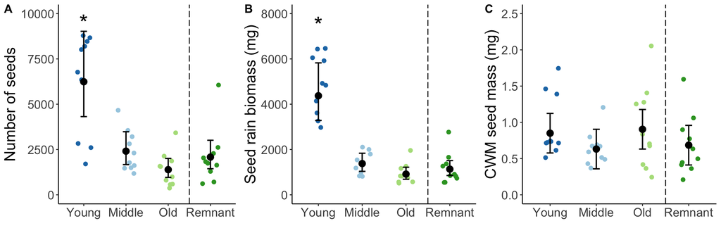

```r
panel_3
```

### Rank abundance curve

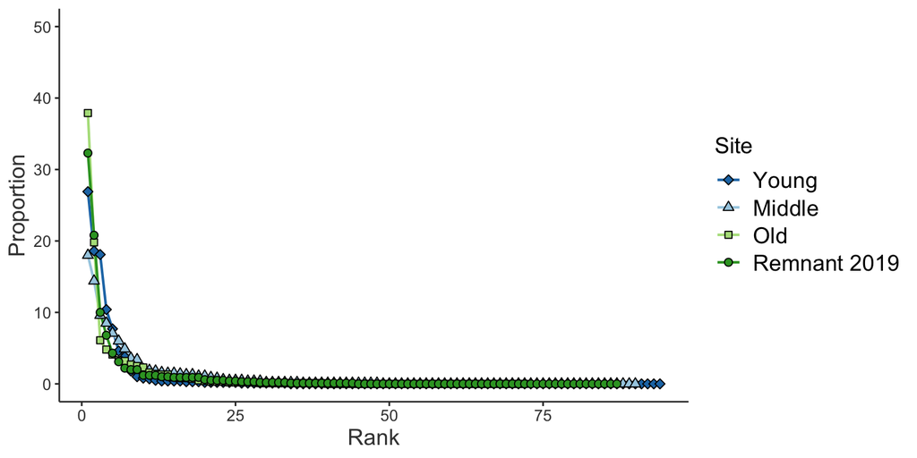